# Shedding light on unconventional opsin gene expression patterns in *Hydra vulgaris*

## Table of Contents:

- Getting Started
  - Loading Packages and Data
- Plotting Opsin Expression
  - **Figure 2** : Plotting expression across cell types in *Hydra*
    - **Figure 2** 0.1% expression cutoff example
    - **Figure 2** 10% expression cutoff example
  - **Figure 3**: Plotting expression across cell states in *Hydra*
  - **Figure 4**: Plotting expression body sections in *Hydra*
  - misc. gene expression tests in discussion
    - Phototransduction cascade
    - Wnt
- Pulling Average Expression Values
- Pulling Metagene Scores

## Getting Started

### Loading Packages and Data

- I will warn that URD usually needs Seurat 2.3 not 5.2.1 and it was very difficult to get both to play nicely when generating the conda environment, there will be a yaml file in the repo but you may need to download some packages individually (see below)
- See Seurat site for installation: https://satijalab.org/seurat/articles/install.html  
  source("https://z.umn.edu/archived-seurat")
- Install URD using these instructions: https://github.com/farrellja/URD/blob/0fed8b824644288ba4ec405ddf82a36960e2d4f9/INSTALL.md \
- I needed to download some dependencies individually before downloading URD  
  conda install -c conda-forge --solver=libmamba r-nloptr  
  conda install -c conda-forge --solver=libmamba r-lme4  
  conda install -c conda-forge --solver=libmamba r-pbkrtest  
  conda install -c conda-forge --solver=libmamba r-car  
  conda install -c conda-forge --solver=libmamba r-vim
- I used this command to download URD  
  Rscript -e 'source("https://raw.githubusercontent.com/farrellja/URD/master/URD-Install.R")'

```r
#load packages
library("ggplot2")
library("Matrix")
library("URD")
library ("Seurat")
library("repr")
```

```r
# CHANGE THIS TO REFLECT THE PATH WHERE YOU SAVED THE HYDRA DATA!
setwd("/kuhpc/scratch/cartwright/m026s156/hydrops/seibert_data")

# Define the output directory
output_dir <- "./output"

# Create it if it doesn't exist
if (!dir.exists(output_dir)) {
  dir.create(output_dir, recursive = TRUE)
}

# Load Hydra Transcriptome Object
hydra <- readRDS("URD_analysis_objects/Hydra_Seurat_Whole_Transcriptome.rds")

# Load URD objects with trees (i.e. branching trajectories)
interstitial <- readRDS("URD_analysis_objects/Hydra_URD_IC.rds")
ectoderm <- readRDS("URD_analysis_objects/Hydra_URD_Ectoderm.rds")
endoderm <- readRDS("URD_analysis_objects/Hydra_URD_Endoderm.rds")

# Load URD objects without trees (i.e. linear trajectories)
male <- readRDS("URD_analysis_objects/Hydra_URD_MaleTranscriptome.rds")
granular.zymogen <- readRDS("URD_analysis_objects/Hydra_URD_GranularZymogen.rds")
spumous <- readRDS("URD_analysis_objects/Hydra_URD_SpumousMucous.rds")

# Load spline curve fits for visualizing gene expression
ectoderm.splines <- readRDS("URD_analysis_objects/Splines-Ectoderm.rds")
endoderm.splines <- readRDS("URD_analysis_objects/Splines-Endoderm.rds")
male.splines <- readRDS("URD_analysis_objects/Splines-MaleTranscriptome.rds")
granular.zymogen.splines <- readRDS("URD_analysis_objects/Splines-GranularZymogen.rds")
spumous.splines <- readRDS("URD_analysis_objects/Splines-SpumousMucous.rds")

#Loading metagene data
meta <- load("gene_regulation_data/Candidate_Regulators/Enrichment_Results/corResults.Rdata")
id_inventory <- read.delim("op3_id_inventory.txt")
```

## Plotting Opsin Expression

- This was adapted from the Plotting Hydra in URD tutorial from the Juliano Lab github: https://github.com/cejuliano/hydra_single_cell/blob/9d2dcb78155a616b22ae019b1c705d56738c1d38/URD_Hydra_Plotting_Tutorial.md

### find gene ID from URD objects

```r
grep("t20729aep", rownames(interstitial@logupx.data), value=T)
grep("t20043aep", rownames(interstitial@logupx.data), value=T)
grep("t20044aep", rownames(interstitial@logupx.data), value=T)
grep("t29150aep", rownames(interstitial@logupx.data), value=T)
grep("t25412aep", rownames(interstitial@logupx.data), value=T)
grep("t3168aep", rownames(interstitial@logupx.data), value=T)
grep("t3233aep", rownames(interstitial@logupx.data), value=T)
grep("t32881aep", rownames(interstitial@logupx.data), value=T)
grep("t3169aep", rownames(interstitial@logupx.data), value=T)
grep("t21413aep", rownames(interstitial@logupx.data), value=T)
grep("t24564aep", rownames(interstitial@logupx.data), value=T)
grep("t31971aep", rownames(interstitial@logupx.data), value=T)
grep("t355aep", rownames(interstitial@logupx.data), value=T)
grep("t10575aep", rownames(interstitial@logupx.data), value=T)
grep("t24044aep", rownames(interstitial@logupx.data), value=T)
grep("t26793aep", rownames(interstitial@logupx.data), value=T)
grep("t9221aep", rownames(interstitial@logupx.data), value=T)
grep("t4885aep", rownames(interstitial@logupx.data), value=T)
grep("t15588aep", rownames(interstitial@logupx.data), value=T)
grep("t24989aep", rownames(interstitial@logupx.data), value=T)
grep("t27882aep", rownames(interstitial@logupx.data), value=T)
grep("t33805aep", rownames(interstitial@logupx.data), value=T)
grep("t37969aep", rownames(interstitial@logupx.data), value=T)
grep("t3337aep", rownames(interstitial@logupx.data), value=T)
grep("t36346aep", rownames(interstitial@logupx.data), value=T)
grep("t33516aep", rownames(interstitial@logupx.data), value=T)
grep("t33517aep", rownames(interstitial@logupx.data), value=T)
grep("t4602aep", rownames(interstitial@logupx.data), value=T)
grep("t26465aep", rownames(interstitial@logupx.data), value=T)
grep("t26466aep", rownames(interstitial@logupx.data), value=T)
grep("t29512aep", rownames(interstitial@logupx.data), value=T)
grep("t33568aep", rownames(interstitial@logupx.data), value=T)
grep("t14044aep", rownames(interstitial@logupx.data), value=T)
grep("t29959aep", rownames(interstitial@logupx.data), value=T)
grep("t17353aep", rownames(interstitial@logupx.data), value=T)
grep("t2106aep", rownames(interstitial@logupx.data), value=T)
grep("t21092aep", rownames(interstitial@logupx.data), value=T)
grep("t27688aep", rownames(interstitial@logupx.data), value=T)
grep("t36136aep", rownames(interstitial@logupx.data), value=T)
grep("t36280aep", rownames(interstitial@logupx.data), value=T)
grep("t4128aep", rownames(interstitial@logupx.data), value=T)
grep("t32850aep", rownames(interstitial@logupx.data), value=T)
grep("t31375aep", rownames(interstitial@logupx.data), value=T)
grep("t20210aep", rownames(interstitial@logupx.data), value=T)
grep("t16278aep", rownames(interstitial@logupx.data), value=T)
```

't20729aep|OPSP_COLLI'

't20043aep|OPSX_HUMAN'

't20044aep'

't29150aep|OPSX_HUMAN'

't25412aep|OPSO_SALSA'

't3168aep|OPN3_HUMAN'

't3233aep'

't32881aep|OPN3_MOUSE'

't3169aep|OPSX_HUMAN'

't21413aep|OPN4_PHOSU'

't24564aep|OPSR_CAPHI'

't31971aep'

't355aep|OPSG3_DANRE'

't10575aep|OPSR_BOVIN'

't24044aep|OPSP_ICTPU'

't26793aep|OPSO_RUTRU'

't9221aep|OPN3_HUMAN'

't4885aep|OPN5_MOUSE'

't15588aep|OPN3_HUMAN'

't27882aep|OPN3_HUMAN'

't33805aep|OPN4B_XENLA'

't37969aep|OPSD_ALLSU'

't3337aep'

't36346aep|OPN3_MOUSE'

't33516aep|OPSD2_MIZYE'

't33517aep|OPSD2_MIZYE'

't4602aep'

't26465aep|OPN3_HUMAN'

't26466aep|OPN3_HUMAN'

't29512aep|OPSP_CHICK'

't33568aep'

't14044aep|OPSD2_MIZYE'

't29959aep|OPN4B_XENLA'

't17353aep|OPN4B_XENLA'

't2106aep|OPN3_HUMAN'

't21092aep|OPSD_LOLFO'

't27688aep|OPSP_COLLI'

't36136aep|OPSD_LOLFO'

't36280aep|OPS2_DROPS'

't4128aep|OPSD2_MIZYE'

't32850aep'

't31375aep|OPSC1_HEMSA'

't20210aep'

't16278aep|OPSC2_HEMSA'

### **Figure 2** : Plotting expression across cell types in *Hydra*

```r
# updates V2 seurat object to V3 (changes | and _ to - in names)
hydraV3 <- UpdateSeuratObject(hydra)

#get list of opsin
new.hydraV3.features <- c(
  "t20729aep-OPSP-COLLI", "t20043aep-OPSX-HUMAN", "t20044aep", "t29150aep-OPSX-HUMAN", "t25412aep-OPSO-SALSA",
  "t3168aep-OPN3-HUMAN", "t3233aep", "t32881aep-OPN3-MOUSE", "t3169aep-OPSX-HUMAN", "t21413aep-OPN4-PHOSU",
  "t24564aep-OPSR-CAPHI", "t31971aep", "t355aep-OPSG3-DANRE", "t10575aep-OPSR-BOVIN", "t24044aep-OPSP-ICTPU",
  "t26793aep-OPSO-RUTRU", "t9221aep-OPN3-HUMAN", "t4885aep-OPN5-MOUSE", "t15588aep-OPN3-HUMAN", "t27882aep-OPN3-HUMAN",
  "t33805aep-OPN4B-XENLA", "t37969aep", "t3337aep", "t36346aep-OPN3-MOUSE", "t33516aep-OPSD2-MIZYE", "t33517aep-OPSD2-MIZYE",
  "t4602aep", "t26465aep-OPN3-HUMAN", "t26466aep-OPN3-HUMAN", "t29512aep-OPSP-CHICK", "t33568aep", "t14044aep-OPSD2-MIZYE",
  "t29959aep-OPN4B-XENLA", "t17353aep-OPN4B-XENLA", "t2106aep-OPN3-HUMAN", "t21092aep-OPSD-LOLFO", "t27688aep-OPSP-COLLI",
  "t36136aep-OPSD-LOLFO", "t36280aep-OPS2-DROPS", "t4128aep-OPSD2-MIZYE", "t31375aep-OPSC1-HEMSA", "t20210aep", "t16278aep-OPSC2-HEMSA",
  "t24989aep", "t32850aep"
)

#To reorder cluster ID's for better readability
#Get the Orders:
#current_levels <- levels(hydraV3)
#print(current_levels)

#make new order
new_order <- c(
  "ecEp_stem_cell", "ecEp-nb(pd)", "ecEp-nem(id)", "ecEp_basal_disk", "ecEp_head",
  "ecEp_battery_cell1(mp)", "ecEp_battery_cell2(mp)", "enEp_stem_cell", "enEp-nb(pd)",
  "enEp-nem(pd)", "enEp_tent-nem(pd)", "enEp_foot", "enEp_head", "enEp_tentacle",
  "i_stem_cell/progenitor", "i_nematocyte", "i_nb1", "i_nb2", "i_nb3", "i_nb4", "i_nb5",
  "i_granular_mucous_gland_cell", "i_spumous_mucous_gland_cell", "i_zymogen_gland_cell",
  "i_male_germline", "i_female_germline1", "i_female_germline2_nurse",
  "i_neuron/gland_cell_progenitor", "i_neuron_progenitor", "i_neuron_ec1", "i_neuron_ec2",
  "i_neuron_ec3", "i_neuron_ec4", "i_neuron_ec5", "i_neuron_en1", "i_neuron_en2",
  "i_neuron_en3", "db")

#reassign new order to hydra V3
levels(hydraV3) <- new_order
```

[output not shown]

#### **Figure 2 Plot**

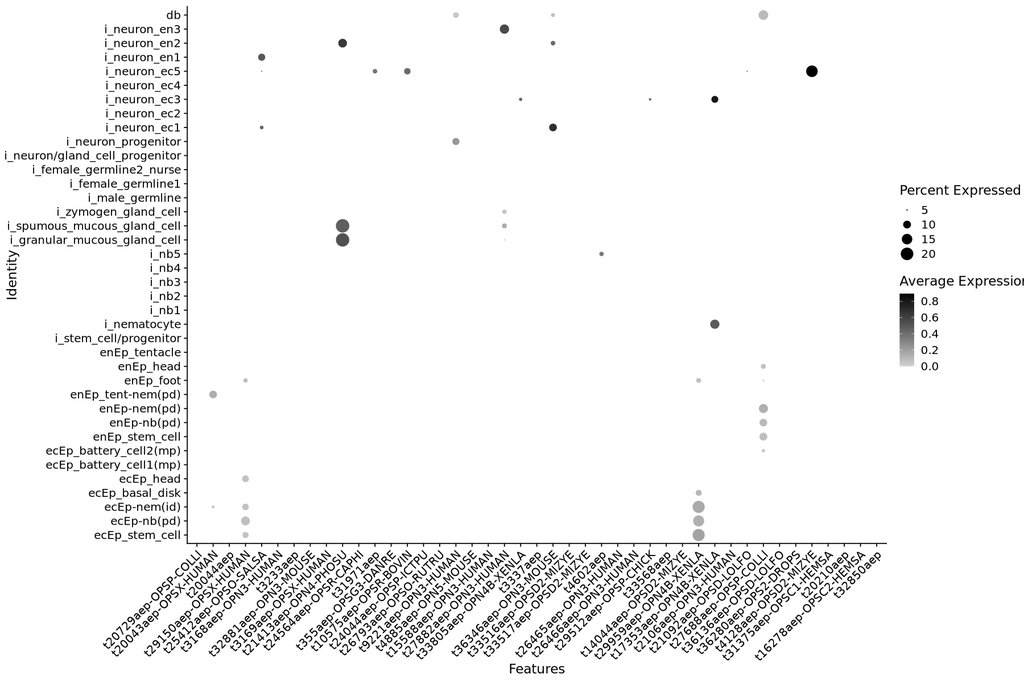

```r
DotPlot(
        object = hydraV3,
        features = new.hydraV3.features,
        cols = c("lightgrey", "black"),
        dot.scale = 6 ,
        dot.min = 0.05, #setting percent expression threshold
        #scale.min =  ,
        cluster.idents = FALSE,
        scale = FALSE, # Make TRUE if you want log normalized, read corrected counts to be scaled as Z scores
        scale.by = "size",
)+ RotatedAxis()
options(repr.plot.width=15, repr.plot.height=10)
```

```r
#If you want PDF output un comment the next and last line

output_file <- file.path(output_dir, "Figure_3_dotplot_5p.tif")
tiff(output_file, width = 15, height = 10, units = "in", res = 300)
DotPlot(
        object = hydraV3,
        features = new.hydraV3.features,
        cols = c("lightgrey", "black"),
        dot.scale = 6 ,
        dot.min = 0.05, #setting percent expression threshold
        #scale.min =  ,
        cluster.idents = FALSE,
        scale = FALSE, # Make TRUE if you want log normalized, read corrected counts to be scaled as Z scores
        scale.by = "size",
)+ RotatedAxis()
dev.off()
#resize plot
#options(repr.plot.width=15, repr.plot.height=10)
```

**pdf:** 2

##### **Figure 2:** 0.1% expression cutoff example

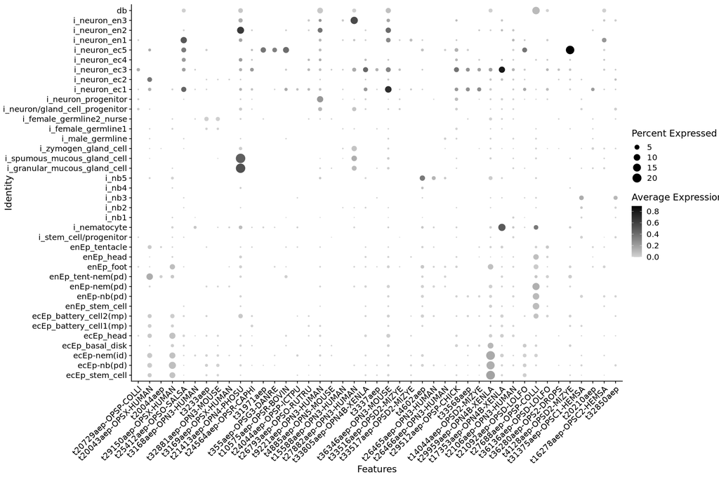

```r
#making opsin dotplot
#If you want PDF output un comment the next and last line
#pdf("./output/Figure_2_dotplot_0.1p.pdf", width = 15, height = 10)
DotPlot(
        object = hydraV3,
        features = new.hydraV3.features,
        cols = c("lightgrey", "black"),
        dot.scale = 6 ,
        dot.min = 0.001, #setting percent expression threshold
        cluster.idents = FALSE,
        scale = FALSE,
        scale.by = "size",
)+ RotatedAxis()
#dev.off()
#resize plot
options(repr.plot.width=15, repr.plot.height=10)
```

##### **Figure 2:** 10% expression cutoff example

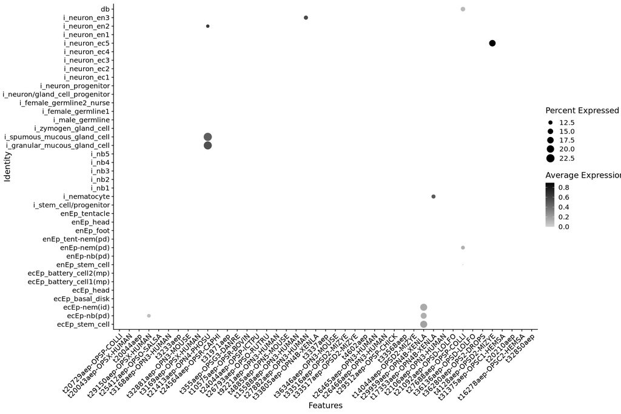

```r
#If you want PDF output un comment the next and last line
#pdf("./output/Figure_2_dotplot_10p.pdf", width = 15, height = 10)
DotPlot(
        object = hydraV3,
        features = new.hydraV3.features,
        cols = c("lightgrey", "black"),
        dot.scale = 6 ,
        dot.min = 0.1, #setting percent expression threshold
        cluster.idents = FALSE,
        scale = FALSE,
        scale.by = "size",
)+ RotatedAxis()
#dev.off()
#resize plot
options(repr.plot.width=15, repr.plot.height=10)
```

### **Figure 3**: Plotting expression across cell states in *Hydra*

```r
# Export opsin plot on interstitial cell lineage
output_file <- file.path(output_dir, "Figure_2_t21413aep_interstitial.tif")
tiff(output_file, width = 10, height = 10, units = "in", res = 300)
plotTree(interstitial,
        "t21413aep|OPN4_PHOSU",
         tree.size = 4,
         cell.size = 2,
         color.limits = c(0,3)
        )
dev.off()

# Export opsin plot on ectodermal cell lineage
output_file <- file.path(output_dir, "Figure_3_t29959aep_ectodermal.tif")
tiff(output_file, width = 10, height = 10, units = "in", res = 300)
plotTree(ectoderm,
         "t29959aep|OPN4B_XENLA",
         tree.size = 4,
         cell.size = 2,
         color.limits = c(0,3)
        )
dev.off()

# Export opsin plot on endodermal lineage
output_file <- file.path(output_dir, "Figure_3_t27688aep_endodermal.tif")
tiff(output_file, width = 10, height = 10, units = "in", res = 300)
plotTree(endoderm,
         "t27688aep|OPSP_COLLI",
         tree.size = 4,
         cell.size = 2,
         color.limits = c(0,3)
         )
dev.off()
```

**pdf:** 2

**pdf:** 2

**pdf:** 2

### **Figure 4** : Plotting expression body sections in *Hydra*

```r
output_file <- file.path(output_dir, "Figure_4_dotplot_5.tif")
tiff(output_file, width = 15, height = 10, units = "in", res = 300)
plotSmoothFitMultiCascade(ectoderm.splines, c("t29150aep|OPSX_HUMAN",
                                              "t20043aep|OPSX_HUMAN",
                                              "t21092aep|OPSD_LOLFO",
                                              "t29959aep|OPN4B_XENLA"), ncol = 1)
dev.off()
```

**pdf:** 2

### Other Gene Expression Patterns

#### Phototransduction cascade

```r
# Phototransduction Cascade Genes from Macias-Munoz et al. 2019 table S3

#Gαs
grep("t12724aep", rownames(interstitial@logupx.data), value=T)
#Gαo
grep("t15699aep", rownames(interstitial@logupx.data), value=T)
#Gαi
grep("t12031aep", rownames(interstitial@logupx.data), value=T)
#Gɣ1
grep("t13138aep", rownames(interstitial@logupx.data), value=T)
#Gɣ2
grep("t26652aep", rownames(interstitial@logupx.data), value=T)
#GRK5-like
grep("t13671aep", rownames(interstitial@logupx.data), value=T)
#GMP-PDEα1
grep("t26867aep", rownames(interstitial@logupx.data), value=T)
#GMP-PDEα2
grep("t38455aep", rownames(interstitial@logupx.data), value=T)
#GMP-PDEβ
grep("t20025aep", rownames(interstitial@logupx.data), value=T)
#GMP-PDEΔ
grep("t25255aep", rownames(interstitial@logupx.data), value=T)
#Phosphodiesterase
grep("t6798aep", rownames(interstitial@logupx.data), value=T)
#CNG
grep("t27655aep", rownames(interstitial@logupx.data), value=T)
#RGS12-like
grep("t26213aep", rownames(interstitial@logupx.data), value=T)
#ANPR1-like
grep("t7063aep", rownames(interstitial@logupx.data), value=T)
#ANPR1-like2
grep("t21324aep", rownames(interstitial@logupx.data), value=T)
#Neurocalcin-like
grep("t38370aep", rownames(interstitial@logupx.data), value=T)
#Gαq
grep("t612aep", rownames(interstitial@logupx.data), value=T)
#PLC
grep("t29781aep", rownames(interstitial@logupx.data), value=T)
#Ankyrin-3-like
grep("t27547aep", rownames(interstitial@logupx.data), value=T)
#Gβ1
grep("t19432aep", rownames(interstitial@logupx.data), value=T)
#Rh kinase
grep("t17074aep", rownames(interstitial@logupx.data), value=T)
#Arrestin
grep("t14420aep", rownames(interstitial@logupx.data), value=T)
#SEC14-like
grep("t7389aep", rownames(interstitial@logupx.data), value=T)

#Additional sequences
#PREDICTED: Hydra vulgaris homeobox protein 2 (LOC124816966), mRNA
grep("t15272aep", rownames(interstitial@logupx.data), value=T)
#ANR28_HUMAN
grep("t911aep", rownames(interstitial@logupx.data), value=T)
#ANR28_MOUSE
grep("t27546aep", rownames(interstitial@logupx.data), value=T)
#ANK1_HUMAN
grep("t11518aep", rownames(interstitial@logupx.data), value=T)
grep("t32411aep", rownames(interstitial@logupx.data), value=T)
grep("t36031aep", rownames(interstitial@logupx.data), value=T)
grep("t28209aep", rownames(interstitial@logupx.data), value=T)
grep("t2619aep", rownames(interstitial@logupx.data), value=T)
grep("t30156aep", rownames(interstitial@logupx.data), value=T)
grep("t25553aep", rownames(interstitial@logupx.data), value=T)
```

't12724aep|GNAS_HOMAM'

't15699aep|GNAO_BOVIN'

't12031aep|GNAI_PATPE'

't13138aep|GBG2_PONAB'

't26652aep|GBG7_HUMAN'

't13671aep|GRK5_BOVIN'

't26867aep|PDE11_MOUSE'

't38455aep|PDE11_DROME'

't20025aep|PDE6_DROMO'

't25255aep|PDE6D_MOUSE'

't6798aep|PDE9A_PANTR'

't27655aep|CNGA3_HUMAN'

't26213aep|RGS12_RAT'

't7063aep|GCY_STRPU'

't21324aep|GC76C_DROME'

't38370aep|NCAH_DROME'

't612aep|GNAQ_MIZYE'

't29781aep|PIP1_DROME'

't27547aep|ANK3_RAT'

't19432aep|GBB_PINFU'

't17074aep|ARBK2_BOVIN'

't14420aep|ARRB1_MACFA'

't7389aep|S14L1_HUMAN'

't15272aep'

't911aep|ANR28_HUMAN'

't27546aep|ANR28_MOUSE'

't11518aep|ANK1_HUMAN'

't32411aep|CNGA2_BOVIN'

't36031aep|ANPRA_MOUSE'

't28209aep'

't2619aep|PIP1_DROME'

't30156aep|PLCB3_HUMAN'

't25553aep|TCB1_CAEBR'

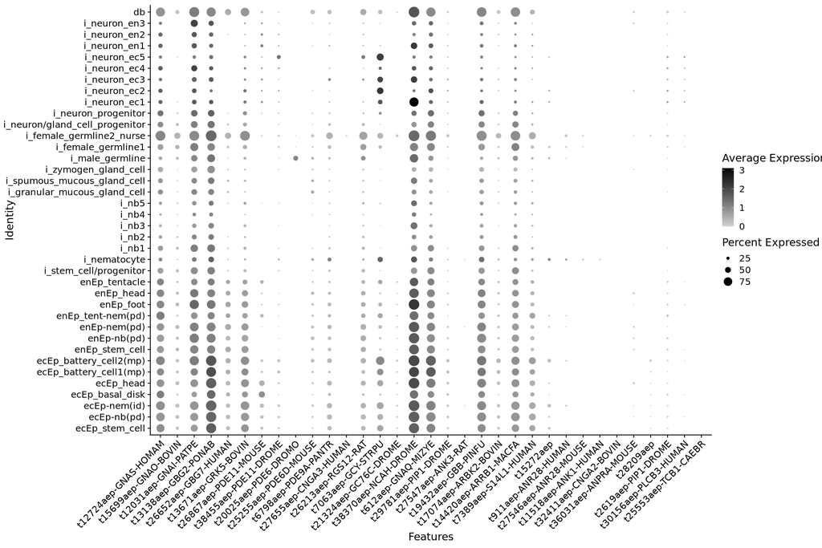

```r
photo_all <- c(
  't12724aep-GNAS-HOMAM',
  't15699aep-GNAO-BOVIN',
  't12031aep-GNAI-PATPE',
  't13138aep-GBG2-PONAB',
  't26652aep-GBG7-HUMAN',
  't13671aep-GRK5-BOVIN',
  't26867aep-PDE11-MOUSE',
  't38455aep-PDE11-DROME',
  't20025aep-PDE6-DROMO',
  't25255aep-PDE6D-MOUSE',
  't6798aep-PDE9A-PANTR',
  't27655aep-CNGA3-HUMAN',
  't26213aep-RGS12-RAT',
  't7063aep-GCY-STRPU',
  't21324aep-GC76C-DROME',
  't38370aep-NCAH-DROME',
  't612aep-GNAQ-MIZYE',
  't29781aep-PIP1-DROME',
  't27547aep-ANK3-RAT',
  't19432aep-GBB-PINFU',
  't17074aep-ARBK2-BOVIN',
  't14420aep-ARRB1-MACFA',
  't7389aep-S14L1-HUMAN',
  't15272aep',
  't911aep-ANR28-HUMAN',
  't27546aep-ANR28-MOUSE',
  't11518aep-ANK1-HUMAN',
  't32411aep-CNGA2-BOVIN',
  't36031aep-ANPRA-MOUSE',
  't28209aep',
  't2619aep-PIP1-DROME',
  't30156aep-PLCB3-HUMAN',
  't25553aep-TCB1-CAEBR'
)

DotPlot(
  object = hydraV3,
  features = photo_all,
  cols = c("lightgrey", "black"),
  dot.scale = 6,
  dot.min = 0.05,  # setting percent expression threshold
  cluster.idents = FALSE,
  scale = FALSE
) + RotatedAxis()

# Resize plot
options(repr.plot.width = 15, repr.plot.height = 10)
```

#### Wnt

```r
# WNT3, pulled from HGP Genome Blast with Human WNT3 as bait sequence (GenBank: AAI03922.1)
grep("t14194aep", rownames(interstitial@logupx.data), value=T)
```

't14194aep|WNT3_MOUSE'

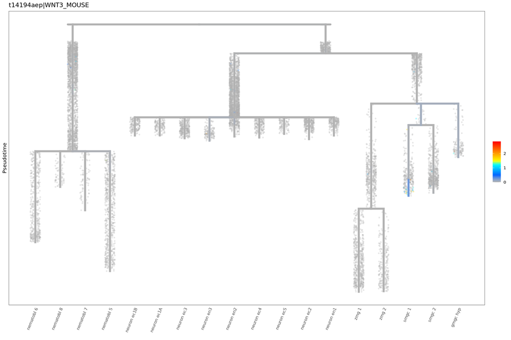

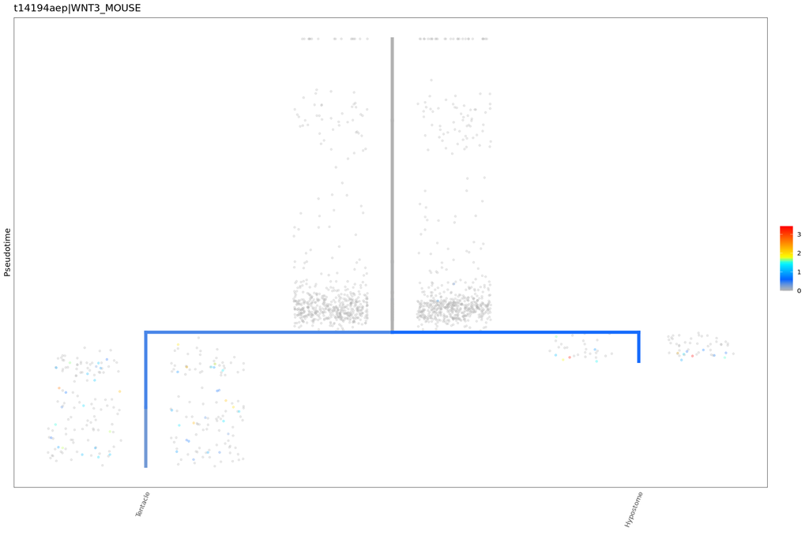

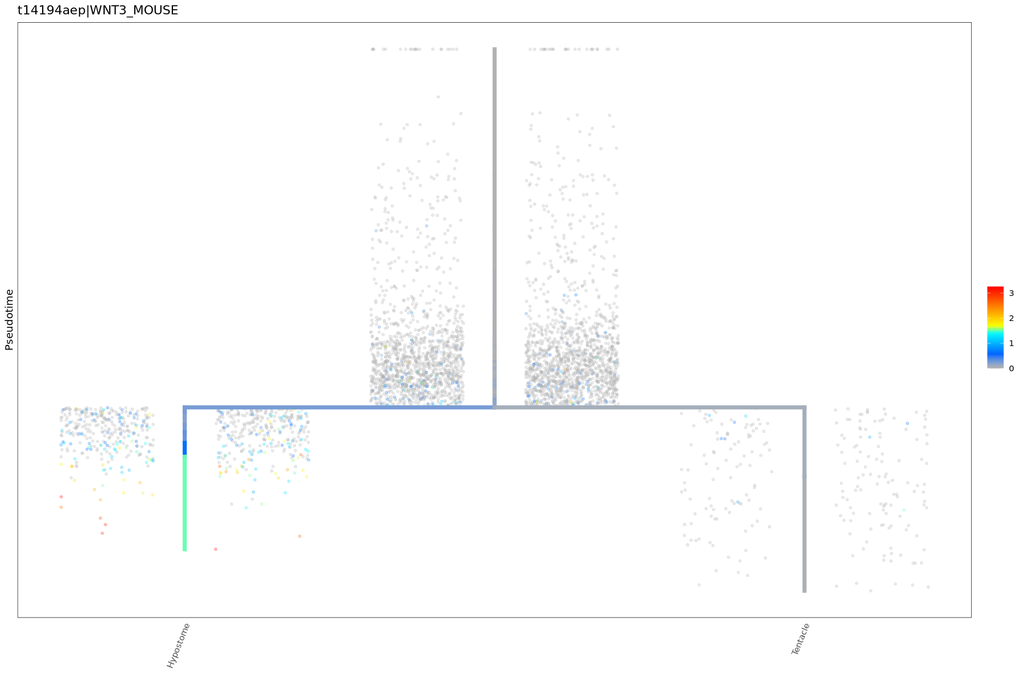

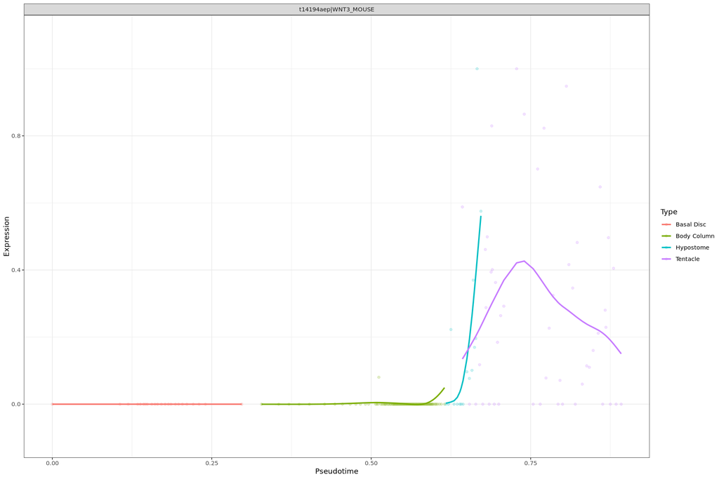

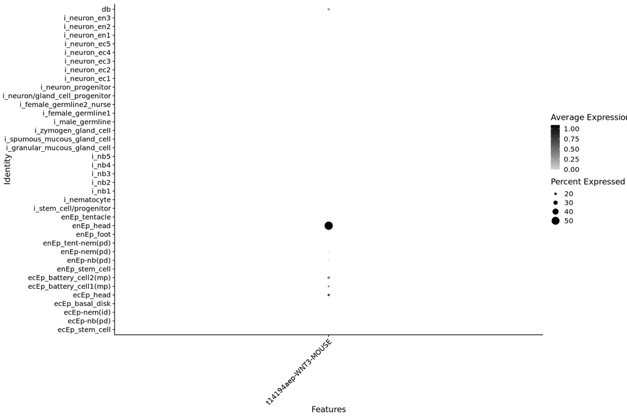

```r
# Export opsin plot on interstitial cell lineage
#pdf("/Users/marina/Desktop/Bioinformatics/Projects/Worster_Hydra_Notebook/opsin_URD_and_Spline_plots/t27688aep|OPSP_COLLI_interstitial_cell_lineage.pdf")
plotTree(interstitial,
        "t14194aep|WNT3_MOUSE",
         tree.size = 2,
         cell.size = 1,
        )
#dev.off()

# Export opsin plot on ectodermal cell lineage
#pdf("/Users/marina/Desktop/Bioinformatics/Projects/Worster_Hydra_Notebook/opsin_URD_and_Spline_plots/t27688aep|OPSP_COLLI_ectodermal_cell_lineage.pdf")
plotTree(ectoderm,
        "t14194aep|WNT3_MOUSE",
         tree.size = 2,
         cell.size = 1,
        )
#dev.off()

# Export opsin plot on endodermal lineage
#pdf("/Users/marina/Desktop/Bioinformatics/Projects/Worster_Hydra_Notebook/opsin_URD_and_Spline_plots/t27688aep|OPSP_COLLI_endodermal_cell_lineage.pdf")
plotTree(endoderm,
        "t14194aep|WNT3_MOUSE",
         tree.size = 2,
         cell.size = 1)
#dev.off()

plotSmoothFitMultiCascade(ectoderm.splines, c("t14194aep|WNT3_MOUSE"))

DotPlot(
  object = hydraV3,
  features = "t14194aep-WNT3-MOUSE",
  cols = c("lightgrey", "black"),
  dot.scale = 6,
  dot.min = 0.05,  # setting percent expression threshold
  cluster.idents = FALSE,
  scale = FALSE
) + RotatedAxis()
```

## Pulling Average Expression Values

```r
avg_expr <- AverageExpression(
  hydraV3,
  assays = "RNA",
  features = new.hydraV3.features,
  return.seurat = FALSE,
  group.by = "ident",
  add.ident = NULL,
  layer = "data",  #data : normalized UMI counts , scaled.data : zscores of data
  verbose = TRUE
)
print (avg_expr)
# Save the average expression result as CSV
write.csv(avg_expr$RNA, file = "./output/hydraV3_average_expression.csv", row.names = TRUE)
```

```
As of Seurat v5, we recommend using AggregateExpression to perform pseudo-bulk analysis.
Names of identity class contain underscores ('_'), replacing with dashes ('-')
Warning message:
“The following 2 features were not found in the RNA assay: t37969aep, t24989aep”
```

```
$RNA
43 x 38 sparse Matrix of class "dgCMatrix"
```

```
  [[ suppressing 38 column names ‘ecEp-stem-cell’, ‘ecEp-nb(pd)’, ‘ecEp-nem(id)’ ... ]]
```

```
t20729aep-OPSP-COLLI  .            .            .            .
t20043aep-OPSX-HUMAN  3.011149e-02 0.0324250400 0.0387039525 0.0020758016
t20044aep             .            .            .            .
t29150aep-OPSX-HUMAN  6.194823e-02 0.0779737214 0.0654059707 0.0227557692
t25412aep-OPSO-SALSA  6.749890e-04 0.0005667497 0.0013937243 0.0081272023
t3168aep-OPN3-HUMAN   8.542744e-04 .            0.0019554651 .
t3233aep              3.038523e-03 0.0192116010 0.0051393376 .
t32881aep-OPN3-MOUSE  4.616382e-03 0.0119607799 0.0042774072 0.0029832651
t3169aep-OPSX-HUMAN   .            .            0.0008104995 .
t21413aep-OPN4-PHOSU  1.614970e-03 0.0036380886 0.0004579642 0.0055775155
t24564aep-OPSR-CAPHI  .            0.0006724458 .            0.0039855691
t31971aep             4.248522e-04 0.0003635349 .            .
t355aep-OPSG3-DANRE   1.718603e-04 0.0006938349 0.0010857366 .
t10575aep-OPSR-BOVIN  6.319976e-04 .            .            0.0021038317
t24044aep-OPSP-ICTPU  1.685853e-03 .            0.0138836977 .
t26793aep-OPSO-RUTRU  8.267352e-04 0.0008573717 .            .
t9221aep-OPN3-HUMAN   1.828216e-03 0.0009944242 0.0075588161 0.0017158286
t4885aep-OPN5-MOUSE   1.127630e-04 .            0.0015677682 0.0016914292
t15588aep-OPN3-HUMAN  .            .            .            .
t27882aep-OPN3-HUMAN  8.291038e-04 0.0036095143 .            .
t33805aep-OPN4B-XENLA 2.693103e-03 0.0008104164 0.0015668005 .
t3337aep              1.376763e-03 0.0011610807 .            .
t36346aep-OPN3-MOUSE  6.490575e-03 0.0058883217 0.0032610227 0.0165442705
t33516aep-OPSD2-MIZYE .            .            .            .
t33517aep-OPSD2-MIZYE 3.789271e-03 0.0029025990 0.0015840480 .
t4602aep              2.614205e-04 0.0057801769 0.0067721562 .
t26465aep-OPN3-HUMAN  .            0.0023519478 .            .
t26466aep-OPN3-HUMAN  .            0.0005922384 .            .
t29512aep-OPSP-CHICK  2.448179e-03 0.0010091235 .            0.0097220512
t33568aep             7.016290e-04 0.0014534176 0.0016774659 0.0040286528
t14044aep-OPSD2-MIZYE 1.220890e-03 0.0017274221 .            0.0109978092
t29959aep-OPN4B-XENLA 2.101342e-01 0.1479241196 0.1694292553 0.1072197434
t17353aep-OPN4B-XENLA 5.246356e-03 0.0029591694 0.0196249993 0.0005521449
t2106aep-OPN3-HUMAN   3.705205e-04 0.0022112268 0.0004655361 .
t21092aep-OPSD-LOLFO  1.958290e-02 0.0173452320 0.0129463186 0.0351483863
t27688aep-OPSP-COLLI  3.593230e-04 0.0020932431 0.0107404735 0.0069125897
t36136aep-OPSD-LOLFO  3.921379e-04 .            .            .
t36280aep-OPS2-DROPS  8.156294e-05 0.0003019418 .            .
t4128aep-OPSD2-MIZYE  2.653569e-03 0.0003635349 .            0.0204143673
t31375aep-OPSC1-HEMSA 8.237775e-04 0.0033811616 0.0005313923 .
```

[output cut: 340 more lines]

```
t29512aep-OPSP-CHICK  0.13840021 0.04580390 .           0.08763167 .
t33568aep             0.01570352 .          .           .          .
t14044aep-OPSD2-MIZYE .          .          0.049776008 .          .
t29959aep-OPN4B-XENLA .          .          0.009514802 .          0.011701768
t17353aep-OPN4B-XENLA .          .          0.092363271 0.05214770 .
t2106aep-OPN3-HUMAN   0.00949848 0.11730664 0.052711887 .          .
t21092aep-OPSD-LOLFO  0.44989266 0.05965555 .           .          .
t27688aep-OPSP-COLLI  .          .          .           .          0.098254147
t36136aep-OPSD-LOLFO  .          0.03170503 .           .          0.003585227
t36280aep-OPS2-DROPS  .          .          .           .          .
t4128aep-OPSD2-MIZYE  1.44176059 .          .           .          .
t31375aep-OPSC1-HEMSA .          .          .           .          .
t20210aep             .          .          0.005695195 .          .
t16278aep-OPSC2-HEMSA 0.01258812 0.26088529 .           0.04091871 0.012552997
t32850aep             .          .          .           0.02343501 .
```

## Pulling Metagene Scores

```r
#Extract each metagene score for each opsin
gene_ids <- id_inventory$gene_ID
gene_ids_noNA <- gene_ids[gene_ids != ""]
gene_ids_noDup <- unique(gene_ids_noNA)
opsinMetagenes <- matrix(nrow = length(gene_ids_noDup), ncol = ncol(corResults.df))
rownames(opsinMetagenes) <- gene_ids_noDup
colnames(opsinMetagenes) <- colnames(corResults.df)
opsinMetagenes <- as.data.frame(opsinMetagenes)

for (i in 1:nrow(opsinMetagenes)) {
  match_rows <- grepl(gene_ids_noDup[i], rownames(corResults.df))

  # Check if there's at least one match
  if (any(match_rows)) {
    opsinMetagenes[i,] <- corResults.df[match_rows,]
  } else {
    # Handle the case where no match is found, e.g., skip or assign default values
    opsinMetagenes[i,] <- NA  # Or assign any default value you prefer
  }
}
```

```r
# Extract the highest scoring metagene for each opsin
# Initialize an empty data frame to store the results
top_opsin_metagene <- data.frame(Row_Name = character(nrow(opsinMetagenes)),
                                 Top_Column = character(nrow(opsinMetagenes)),
                                 Max_Value = numeric(nrow(opsinMetagenes)),
                                 stringsAsFactors = FALSE)

# Loop over each row to find the column with the highest value
for (i in 1:nrow(opsinMetagenes)) {
  # Ensure that only numeric columns are considered
  numeric_data <- opsinMetagenes[i, sapply(opsinMetagenes, is.numeric)]

  # If there are any numeric values, find the column with the max value
  if (length(numeric_data) > 0 && any(!is.na(numeric_data))) {
    # Check if 'wg' is present in the numeric columns
    if ("wg" %in% colnames(numeric_data)) {
      max_col <- "wg"
      max_val <- numeric_data["wg"]
    } else {
      max_col <- colnames(numeric_data)[which.max(numeric_data)]
      max_val <- max(numeric_data, na.rm = TRUE)
    }

    # Store the row name, column name, and maximum value in the result matrix
    top_opsin_metagene[i,] <- c(rownames(opsinMetagenes)[i], max_col, max_val)
  } else {
    # If no numeric data in the row (or all NA values), assign NA for both column and max value
    top_opsin_metagene[i,] <- c(rownames(opsinMetagenes)[i], NA, NA)
  }
}
```

```r
# Metagenes associated with Opsins found in the Hydra Single Cell Dataset
# Print the resulting data frame
print(top_opsin_metagene)

# Export the top_opsin_metagene data frame to a CSV file, including row names
write.csv(top_opsin_metagene, "./output/top_opsin_metagene.csv", row.names = TRUE)
```

```
    Row_Name Top_Column         Max_Value
1  g18853.t1       wg23 0.142015388708641
2  g10186.t1       wg30 0.124216173636526
3  g10185.t1       wg17 0.132939685540326
4  g30488.t1       wg63 0.154133640962899
5  g25858.t1       wg50 0.154343782056708
6  g25854.t1       <NA>              <NA>
7  g13691.t1       wg76 0.263805977917493
8   g3548.t1       <NA>              <NA>
9   g3547.t1       wg29 0.315885592889302
10  g3546.t1       wg29 0.239018118000062
11  g3536.t1       <NA>              <NA>
12  g3518.t1       <NA>              <NA>
13 g28613.t1       <NA>              <NA>
14 g28610.t1       wg22 0.177484082506587
15 g28609.t1       <NA>              <NA>
16  g1616.t1       wg23 0.259531812002445
17 g15899.t1       <NA>              <NA>
18 g15864.t1       <NA>              <NA>
19 g15863.t1       wg63 0.229893578265267
20 g17463.t2       <NA>              <NA>
21 g17463.t1       wg44   0.1526291993288
22 g25557.t1       wg16 0.252367448169969
23 g25553.t1       <NA>              <NA>
24 g25552.t1       <NA>              <NA>
25 g26211.t1       wg55 0.111458823939634
26 g29332.t1       wg21 0.250825463489907
27 g21488.t1       wg17 0.116077362706482
28         -       <NA>              <NA>
```